# Analisis Discriminante Lineal (LDA)

Anemia infantil - ENDES 2024 (RECH6)

Zulema Luque Cornejo - Universidad Nacional del Altiplano

21 de Junio de 2026

# 1 Introduccion

Este documento desarrolla un **Analisis Discriminante Lineal (LDA)** sobre el dataset de anemia infantil de la encuesta **ENDES 2024 (modulo RECH6)**, siguiendo la metodologia de los 6 pasos descrita en el material de clase (*Analisis discriminante lineal (LDA)*, Dr. Edgar Eloy Carpio Vargas, FINESI-2024).

> Este documento contiene **unicamente el analisis LDA (lineal)**. El analisis QDA (cuadratico) esta en un documento `.Rmd` separado.

## 1.1 Variable dependiente (Y)

`grupo_anemia`, con 2 categorias:

- **Sin_anemia**: ninos clasificados sin anemia (Directriz OMS 2024 / RM 251-2024-MINSA)
- **Con_anemia**: ninos con anemia (Leve, Moderada o Grave agrupadas)

## 1.2 Variables independientes (X)

Todas cuantitativas, tal como exige el LDA:

| Variable | Descripcion | Codigo ENDES |
| --- | --- | --- |
| `edad_meses` | Edad del nino en meses | HC1 |
| `peso_kg` | Peso en kilogramos | HC2 |
| `talla_cm` | Talla en centimetros | HC3 |
| `talla_edad_z` | Z-score Talla/Edad (OMS) | HC70 |
| `peso_edad_z` | Z-score Peso/Edad (OMS) | HC71 |

> Se excluye la hemoglobina como predictor porque es la variable que **define** la anemia (evitar circularidad / fuga de informacion).

```r
install.packages(c("MASS", "ggplot2", "gridExtra", "ggpubr", "biotools", "MVN",
                    "caret", "pROC", "ROCR", "dplyr", "reshape2", "knitr", "klaR"))
```

# 2 Librerias

```r
library(MASS)        # lda()
library(ggplot2)
library(gridExtra)
library(ggpubr)
library(biotools)    # boxM()
library(MVN)         # normalidad multivariante
library(caret)       # confusionMatrix, createDataPartition
library(pROC)        # curva ROC
library(dplyr)
library(reshape2)
library(knitr)
library(klaR)         # partimat()

set.seed(123)
options(scipen = 999)
```

> **Tip si un paquete te tira “unused argument” o “could not find function”:** suele significar que tienes una version mas nueva (o mas vieja) del paquete que cambio sus nombres de argumentos o de funciones. Ejecuta `packageVersion("nombre_paquete")` para ver tu version. En este documento ya se ajusto el bloque de `MVN` para la version 6.x (ver mas abajo).

# 3 Preparacion del dataset desde el archivo crudo

El archivo de ENDES viene separado por `;` y usa **codigos numericos para “valor no medido”**, definidos por el propio diccionario de variables del INEI (`Diccionario_RECH6.pdf`). Estos codigos **no son datos reales** y deben excluirse antes de cualquier analisis estadistico:

| Variable | Significado | Rango valido (diccionario) | Codigo de “no medido” |
| --- | --- | --- | --- |
| HC2 | Peso en kg (x10, 1 decimal) | 15:500 | 9999 |
| HC3 | Talla en cm (x10, 1 decimal) | 400:1500 | 9999 |
| HC70 | Z-score Talla/Edad (OMS) | -450:500 | 9996, 9997, 9998 |
| HC71 | Z-score Peso/Edad (OMS) | -450:500 | 9996, 9997, 9998 |
| HC57A | Nivel de anemia (OMS 2024) | 1:4 | 9 (No sabe / no determinado) |

No se descarta ningun otro dato ni se modifican valores reales de ningun nino.

```r
df_crudo <- read.csv("RECH6_2024.csv", sep = ";", stringsAsFactors = FALSE)
cat("Dataset original (crudo):", dim(df_crudo), "\n")
```

```
## Dataset original (crudo): 20290 43
```

```r
datos <- df_crudo[, c("HC1", "HC2", "HC3", "HC57A", "HC70", "HC71")]
colnames(datos) <- c("edad_meses", "peso_kg_x10", "talla_cm_x10",
                      "anemia_oms", "talla_edad_z_x100", "peso_edad_z_x100")

# --- Paso A: excluir codigos de "no medido" segun el diccionario INEI ---
mask_validos <- (
  (datos$peso_kg_x10 < 999) &                          # 9999 = no medido
    (datos$talla_cm_x10 < 9999) &                       # 9999 = no medido
    (datos$anemia_oms %in% c(1, 2, 3, 4)) &             # excluye 9 = No sabe
    (abs(datos$talla_edad_z_x100) < 9000) &             # excluye 9996/9997/9998
    (abs(datos$peso_edad_z_x100) < 9000)                # excluye 9996/9997/9998
)
cat("\nFilas excluidas por codigo de 'no medido':", sum(!mask_validos), "\n")
```

```
##
## Filas excluidas por codigo de 'no medido': 1984
```

```r
cat("Filas que quedan con datos validos:", sum(mask_validos), "de", nrow(datos), "\n")
```

```
## Filas que quedan con datos validos: 18306 de 20290
```

```r
datos <- datos[mask_validos, ]

# --- Paso B: convertir a unidades reales ---
datos$peso_kg <- datos$peso_kg_x10 / 10
datos$talla_cm <- datos$talla_cm_x10 / 10
datos$talla_edad_z <- datos$talla_edad_z_x100 / 100
datos$peso_edad_z <- datos$peso_edad_z_x100 / 100

# --- Paso C: agrupar anemia en 2 categorias (variable dependiente) ---
datos$grupo_anemia <- ifelse(datos$anemia_oms == 4, "Sin_anemia", "Con_anemia")

datos <- datos[, c("edad_meses", "peso_kg", "talla_cm", "talla_edad_z",
                    "peso_edad_z", "anemia_oms", "grupo_anemia")]
datos$grupo_anemia <- as.factor(datos$grupo_anemia)

X_cols <- c("edad_meses", "peso_kg", "talla_cm", "talla_edad_z", "peso_edad_z")

cat("\nDataset final, listo para el analisis discriminante:\n")
```

```
##
## Dataset final, listo para el analisis discriminante:
```

```r
cat(dim(datos), "\n")
```

```
## 18306 7
```

# 4 Paso 1: Revision de los datos

```r
str(datos)
```

```
## 'data.frame':    18306 obs. of  7 variables:
##  $ edad_meses  : int  43 13 19 13 18 54 21 42 53 14 ...
##  $ peso_kg     : num  15 9.1 11.9 10 11.2 16.7 9.6 14.3 14.6 9.9 ...
##  $ talla_cm    : num  96.2 71.4 80.2 74.7 79.5 ...
##  $ talla_edad_z: num  -0.88 -1.67 -0.78 -0.27 -1.19 -1.19 -2.05 -0.87 -0.67 -0.24 ...
##  $ peso_edad_z : num  -0.1 -0.17 0.91 0.67 0.13 -0.25 -1.07 -0.62 -1.14 0.28 ...
##  $ anemia_oms  : int  4 4 4 2 4 4 4 4 3 2 ...
##  $ grupo_anemia: Factor w/ 2 levels "Con_anemia","Sin_anemia": 2 2 2 1 2 2 2 2 1 1 ...
```

```r
cat("\nDistribucion de la variable dependiente:\n")
```

```
##
## Distribucion de la variable dependiente:
```

```r
print(table(datos$grupo_anemia))
```

```
##
## Con_anemia Sin_anemia
##       5754      12552
```

```r
print(round(prop.table(table(datos$grupo_anemia)) * 100, 2))
```

```
##
## Con_anemia Sin_anemia
##      31.43      68.57
```

```r
cat("\nResumen de los predictores:\n")
```

```
##
## Resumen de los predictores:
```

```r
print(summary(datos[, X_cols]))
```

```
##    edad_meses       peso_kg         talla_cm       talla_edad_z
##  Min.   : 6.00   Min.   : 4.90   Min.   : 55.20   Min.   :-5.5100
##  1st Qu.:19.00   1st Qu.:10.60   1st Qu.: 79.60   1st Qu.:-1.5500
##  Median :33.00   Median :13.10   Median : 89.90   Median :-0.8800
##  Mean   :32.53   Mean   :13.27   Mean   : 88.89   Mean   :-0.8778
##  3rd Qu.:46.00   3rd Qu.:15.60   3rd Qu.: 98.30   3rd Qu.:-0.2000
##  Max.   :59.00   Max.   :31.90   Max.   :119.00   Max.   : 3.5400
##   peso_edad_z
##  Min.   :-4.5400
##  1st Qu.:-0.8300
##  Median :-0.1800
##  Mean   :-0.1423
##  3rd Qu.: 0.4900
##  Max.   : 4.4300
```

```r
kable(head(datos, 10), caption = "Primeras 10 observaciones del dataset preparado")
```

Primeras 10 observaciones del dataset preparado

|  | edad_meses | peso_kg | talla_cm | talla_edad_z | peso_edad_z | anemia_oms | grupo_anemia |
| --- | --- | --- | --- | --- | --- | --- | --- |
| 1 | 43 | 15.0 | 96.2 | -0.88 | -0.10 | 4 | Sin_anemia |
| 2 | 13 | 9.1 | 71.4 | -1.67 | -0.17 | 4 | Sin_anemia |
| 3 | 19 | 11.9 | 80.2 | -0.78 | 0.91 | 4 | Sin_anemia |
| 4 | 13 | 10.0 | 74.7 | -0.27 | 0.67 | 2 | Con_anemia |
| 5 | 18 | 11.2 | 79.5 | -1.19 | 0.13 | 4 | Sin_anemia |
| 6 | 54 | 16.7 | 101.2 | -1.19 | -0.25 | 4 | Sin_anemia |
| 7 | 21 | 9.6 | 77.7 | -2.05 | -1.07 | 4 | Sin_anemia |
| 8 | 42 | 14.3 | 96.7 | -0.87 | -0.62 | 4 | Sin_anemia |
| 9 | 53 | 14.6 | 103.0 | -0.67 | -1.14 | 3 | Con_anemia |
| 11 | 14 | 9.9 | 76.7 | -0.24 | 0.28 | 2 | Con_anemia |

## 4.1 Exploracion grafica

Histogramas de cada predictor, separados por grupo de anemia:

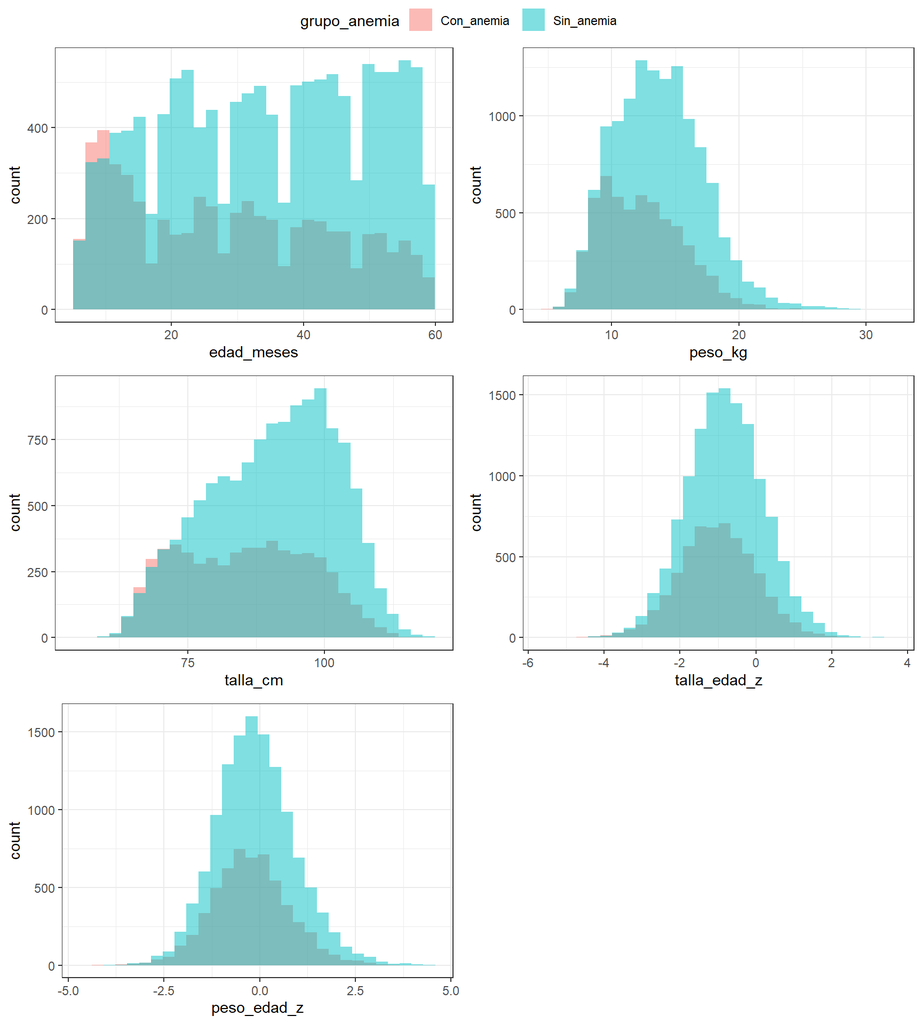

```r
p1 <- ggplot(datos, aes(x = edad_meses, fill = grupo_anemia)) +
  geom_histogram(position = "identity", alpha = 0.5, bins = 30) + theme_bw()
p2 <- ggplot(datos, aes(x = peso_kg, fill = grupo_anemia)) +
  geom_histogram(position = "identity", alpha = 0.5, bins = 30) + theme_bw()
p3 <- ggplot(datos, aes(x = talla_cm, fill = grupo_anemia)) +
  geom_histogram(position = "identity", alpha = 0.5, bins = 30) + theme_bw()
p4 <- ggplot(datos, aes(x = talla_edad_z, fill = grupo_anemia)) +
  geom_histogram(position = "identity", alpha = 0.5, bins = 30) + theme_bw()
p5 <- ggplot(datos, aes(x = peso_edad_z, fill = grupo_anemia)) +
  geom_histogram(position = "identity", alpha = 0.5, bins = 30) + theme_bw()

ggarrange(p1, p2, p3, p4, p5, nrow = 3, ncol = 2, common.legend = TRUE)
```

Dispersion entre pares de variables (similar a `pairs()` del ejemplo de insectos):

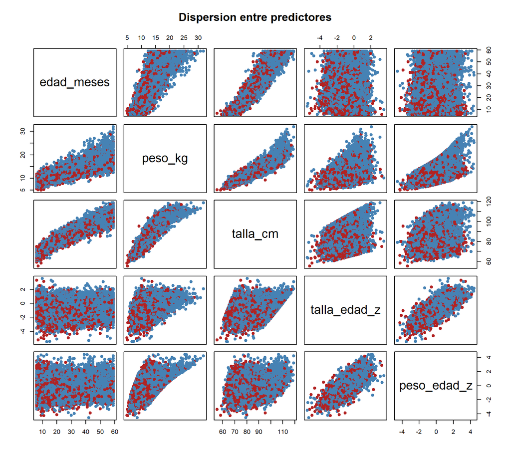

```r
pairs(x = datos[, X_cols],
      col = c("firebrick", "steelblue")[datos$grupo_anemia], pch = 19,
      main = "Dispersion entre predictores")
```

## 4.2 Probabilidades previas (prior probabilities)

```r
print(round(prop.table(table(datos$grupo_anemia)), 4))
```

```
##
## Con_anemia Sin_anemia
##     0.3143     0.6857
```

# 5 Paso 2: Dividir los datos (train / test)

Se divide el dataset en 70% entrenamiento y 30% prueba, manteniendo la proporcion de clases (muestreo estratificado).

```r
index <- createDataPartition(y = datos$grupo_anemia, p = 0.70, list = FALSE)
train <- datos[index, ]
test  <- datos[-index, ]
cat("Train:", nrow(train), " | Test:", nrow(test), "\n")
```

```
## Train: 12815  | Test: 5491
```

# 6 Supuestos del Analisis Discriminante

## 6.1 Supuesto 1: Normalidad univariante (Shapiro-Wilk)

**Ho:** la variable se distribuye normalmente dentro de cada grupo.

```r
# Shapiro requiere n <= 5000; se toma una submuestra de 500 por grupo
datos_tidy <- melt(datos[, c(X_cols, "grupo_anemia")], id.vars = "grupo_anemia")

shapiro_resultados <- datos_tidy %>%
  group_by(grupo_anemia, variable) %>%
  summarise(p_value_Shapiro = {
    muestra <- value
    if (length(muestra) > 500) muestra <- sample(muestra, 500)
    round(shapiro.test(muestra)$p.value, 6)
  }, .groups = "drop")

kable(shapiro_resultados, caption = "Test de Shapiro-Wilk por variable y grupo")
```

Test de Shapiro-Wilk por variable y grupo

| grupo_anemia | variable | p_value_Shapiro |
| --- | --- | --- |
| Con_anemia | edad_meses | 0.000000 |
| Con_anemia | peso_kg | 0.000000 |
| Con_anemia | talla_cm | 0.000000 |
| Con_anemia | talla_edad_z | 0.281369 |
| Con_anemia | peso_edad_z | 0.000060 |
| Sin_anemia | edad_meses | 0.000000 |
| Sin_anemia | peso_kg | 0.000001 |
| Sin_anemia | talla_cm | 0.000000 |
| Sin_anemia | talla_edad_z | 0.497131 |
| Sin_anemia | peso_edad_z | 0.000258 |

QQ-plots de cada variable por grupo:

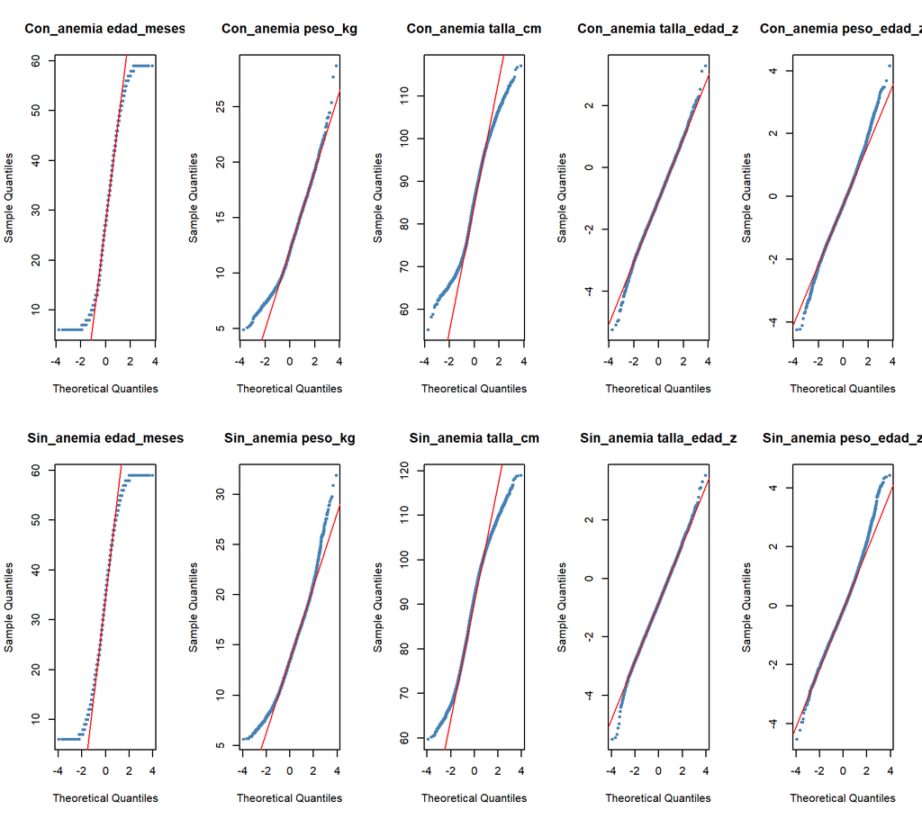

```r
par(mfcol = c(2, 5))
for (col in X_cols) {
  for (grp in levels(datos$grupo_anemia)) {
    x <- datos[datos$grupo_anemia == grp, col]
    qqnorm(x, main = paste(grp, col), pch = 19, col = "steelblue", cex = 0.5)
    qqline(x, col = "red")
  }
}
```

> Con un tamano de muestra grande, Shapiro-Wilk tiende a rechazar Ho ante desviaciones minimas de la normalidad. Se complementa con los QQ-plots, recordando que el LDA es razonablemente robusto a apartamientos moderados de la normalidad.

## 6.2 Supuesto 2: Normalidad multivariante

Se contrasta con los tres test mas usados: Mardia, Henze-Zirkler y Royston (sobre una submuestra de 2000 observaciones por costo computacional).

> **Nota de compatibilidad:** el paquete `MVN` cambio su sintaxis en la version 6.x. El argumento ahora se llama `mvn_test` (antes `mvnTest`) y los resultados se extraen con `summary(resultado, select = "mvn")` en vez de `resultado$multivariateNormality`. Este codigo funciona con `packageVersion("MVN")` 6.x. Si tienes una version 5.x instalada, cambia `mvn_test` por `mvnTest` y usa `resultado$multivariateNormality` directamente.

```r
set.seed(1)
muestra_mvn <- datos[sample(nrow(datos), min(2000, nrow(datos))), X_cols]

result_mardia <- mvn(data = muestra_mvn, mvn_test = "mardia")
cat("--- Test de Mardia ---\n")
```

```
## --- Test de Mardia ---
```

```r
print(summary(result_mardia, select = "mvn"))
```

```
##              Test Statistic p.value     Method          MVN
## 1 Mardia Skewness  5571.144  <0.001 asymptotic ✗ Not normal
## 2 Mardia Kurtosis    57.438  <0.001 asymptotic ✗ Not normal
## $multivariate_normality
##              Test Statistic p.value     Method          MVN
## 1 Mardia Skewness  5571.144  <0.001 asymptotic ✗ Not normal
## 2 Mardia Kurtosis    57.438  <0.001 asymptotic ✗ Not normal
##
## $univariate_normality
##               Test     Variable Statistic p.value    Normality
## 1 Anderson-Darling   edad_meses    21.901  <0.001 ✗ Not normal
## 2 Anderson-Darling      peso_kg     5.471  <0.001 ✗ Not normal
## 3 Anderson-Darling     talla_cm    12.078  <0.001 ✗ Not normal
## 4 Anderson-Darling talla_edad_z     0.423   0.321     ✓ Normal
## 5 Anderson-Darling  peso_edad_z     3.161  <0.001 ✗ Not normal
```

[output cut: 2026 more lines]

```r
result_hz <- mvn(data = muestra_mvn, mvn_test = "hz")
cat("\n--- Test de Henze-Zirkler ---\n")
```

```
##
## --- Test de Henze-Zirkler ---
```

```r
print(summary(result_hz, select = "mvn"))
```

```
##            Test Statistic p.value     Method          MVN
## 1 Henze-Zirkler    23.578  <0.001 asymptotic ✗ Not normal
## $multivariate_normality
##            Test Statistic p.value     Method          MVN
## 1 Henze-Zirkler    23.578  <0.001 asymptotic ✗ Not normal
##
## $univariate_normality
##               Test     Variable Statistic p.value    Normality
## 1 Anderson-Darling   edad_meses    21.901  <0.001 ✗ Not normal
## 2 Anderson-Darling      peso_kg     5.471  <0.001 ✗ Not normal
## 3 Anderson-Darling     talla_cm    12.078  <0.001 ✗ Not normal
## 4 Anderson-Darling talla_edad_z     0.423   0.321     ✓ Normal
## 5 Anderson-Darling  peso_edad_z     3.161  <0.001 ✗ Not normal
##
## $descriptives
```

[output cut: 2024 more lines]

```r
result_royston <- mvn(data = muestra_mvn, mvn_test = "royston")
cat("\n--- Test de Royston ---\n")
```

```
##
## --- Test de Royston ---
```

```r
print(summary(result_royston, select = "mvn"))
```

```
##      Test Statistic p.value     Method          MVN
## 1 Royston   179.956  <0.001 asymptotic ✗ Not normal
## $multivariate_normality
##      Test Statistic p.value     Method          MVN
## 1 Royston   179.956  <0.001 asymptotic ✗ Not normal
##
## $univariate_normality
##               Test     Variable Statistic p.value    Normality
## 1 Anderson-Darling   edad_meses    21.901  <0.001 ✗ Not normal
## 2 Anderson-Darling      peso_kg     5.471  <0.001 ✗ Not normal
## 3 Anderson-Darling     talla_cm    12.078  <0.001 ✗ Not normal
## 4 Anderson-Darling talla_edad_z     0.423   0.321     ✓ Normal
## 5 Anderson-Darling  peso_edad_z     3.161  <0.001 ✗ Not normal
##
## $descriptives
```

[output cut: 2024 more lines]

## 6.3 Supuesto 3: Homogeneidad de matrices de covarianza (Test M de Box)

**Ho:** las matrices de covarianza son iguales entre grupos. Es el supuesto clave que justifica el uso del LDA (covarianza compartida entre grupos).

```r
box_result <- boxM(data = datos[, X_cols], grouping = datos$grupo_anemia)
print(box_result)
```

```
##
##  Box's M-test for Homogeneity of Covariance Matrices
##
## data:  datos[, X_cols]
## Chi-Sq (approx.) = 2277.8, df = 15, p-value < 0.00000000000000022
```

```r
if (box_result$p.value < 0.001) {
  cat("**-> Se RECHAZA Ho** (criterio conservador p < 0.001). ",
      "Las matrices de covarianza NO son homogeneas. El LDA sigue siendo valido como ",
      "primera aproximacion, pero conviene tener en cuenta esta limitacion al interpretar los resultados.")
} else {
  cat("**-> No se rechaza Ho.** Las matrices de covarianza pueden considerarse homogeneas, LDA es adecuado.")
}
```

**-> Se RECHAZA Ho** (criterio conservador p < 0.001). Las matrices de covarianza NO son homogeneas. El LDA sigue siendo valido como primera aproximacion, pero conviene tener en cuenta esta limitacion al interpretar los resultados.

# 7 Paso 3: Entrenamiento del modelo LDA (procedimiento de Fisher)

```r
modelo_lda <- lda(grupo_anemia ~ edad_meses + peso_kg + talla_cm +
                     talla_edad_z + peso_edad_z, data = train)
modelo_lda
```

```
## Call:
## lda(grupo_anemia ~ edad_meses + peso_kg + talla_cm + talla_edad_z +
##     peso_edad_z, data = train)
##
## Prior probabilities of groups:
## Con_anemia Sin_anemia
##  0.3143192  0.6856808
##
## Group means:
##            edad_meses  peso_kg talla_cm talla_edad_z peso_edad_z
## Con_anemia   28.55362 12.34367 85.42577   -1.0205437  -0.2341261
## Sin_anemia   34.29418 13.68828 90.42810   -0.8171902  -0.1000376
##
## Coefficients of linear discriminants:
##                      LD1
## edad_meses   -0.05250762
## peso_kg      -0.18948319
## talla_cm      0.20084055
## talla_edad_z -0.19646087
## peso_edad_z   0.28629042
```

```r
cat("\nProporcion de traza (poder discriminante de cada funcion):\n")
```

```
##
## Proporcion de traza (poder discriminante de cada funcion):
```

```r
print(modelo_lda$svd^2 / sum(modelo_lda$svd^2))
```

```
## [1] 1
```

## 7.1 Correlacion canonica y autovalor

```r
lambda1 <- modelo_lda$svd[1]^2
corr_canonica <- sqrt(lambda1 / (1 + lambda1))
cat("Autovalor (lambda1) =", round(lambda1, 4), "\n")
```

```
## Autovalor (lambda1) = 551.6195
```

```r
cat("Correlacion canonica =", round(corr_canonica, 4), "\n")
```

```
## Correlacion canonica = 0.9991
```

## 7.2 Lambda de Wilks (significancia de la funcion discriminante)

**Ho:** las medias de la funcion discriminante son iguales en todos los grupos.

```r
wilks_lambda <- 1 / (1 + lambda1)
n_train <- nrow(train)
p <- length(X_cols)
g <- nlevels(train$grupo_anemia)

gl_wilks <- p * (g - 1)
chi2_wilks <- -(n_train - 1 - (p + g) / 2) * log(wilks_lambda)
p_wilks <- 1 - pchisq(chi2_wilks, gl_wilks)

cat("Lambda de Wilks =", round(wilks_lambda, 5), "\n")
```

```
## Lambda de Wilks = 0.00181
```

```r
cat("Chi-cuadrado aproximado =", round(chi2_wilks, 3), " gl =", gl_wilks, "\n")
```

```
## Chi-cuadrado aproximado = 80894.08  gl = 5
```

```r
cat("p-value =", format.pval(p_wilks, digits = 6), "\n")
```

```
## p-value = < 0.000000000000000222
```

```r
if (p_wilks < 0.05) {
  cat("**-> Se rechaza Ho:** la funcion discriminante **SI** es estadisticamente significativa.")
} else {
  cat("**-> No se rechaza Ho:** la funcion discriminante no resulta significativa.")
}
```

**-> Se rechaza Ho:** la funcion discriminante **SI** es estadisticamente significativa.

# 8 Paso 4: Evaluacion del modelo

## 8.1 Matriz de confusion

```r
pred_lda <- predict(modelo_lda, newdata = test)
tabla_lda <- table(test$grupo_anemia, pred_lda$class,
                    dnn = c("Clase real", "Clase predicha"))
tabla_lda
```

```
##             Clase predicha
## Clase real   Con_anemia Sin_anemia
##   Con_anemia        147       1579
##   Sin_anemia        145       3620
```

```r
confusionMatrix(pred_lda$class, test$grupo_anemia)
```

```
## Confusion Matrix and Statistics
##
##             Reference
## Prediction   Con_anemia Sin_anemia
##   Con_anemia        147        145
##   Sin_anemia       1579       3620
##
##                Accuracy : 0.686
##                  95% CI : (0.6736, 0.6983)
##     No Information Rate : 0.6857
##     P-Value [Acc > NIR] : 0.4833
##
##                   Kappa : 0.0602
##
##  Mcnemar's Test P-Value : <0.0000000000000002
##
##             Sensitivity : 0.08517
##             Specificity : 0.96149
##          Pos Pred Value : 0.50342
##          Neg Pred Value : 0.69629
##              Prevalence : 0.31433
##          Detection Rate : 0.02677
##    Detection Prevalence : 0.05318
##       Balanced Accuracy : 0.52333
##
##        'Positive' Class : Con_anemia
##
```

```r
error_lda <- mean(test$grupo_anemia != pred_lda$class) * 100
cat("Error de clasificacion LDA (test) =", round(error_lda, 2), "%\n")
```

```
## Error de clasificacion LDA (test) = 31.4 %
```

## 8.2 Validacion cruzada 10-fold

```r
lda_cv <- train(grupo_anemia ~ edad_meses + peso_kg + talla_cm +
                   talla_edad_z + peso_edad_z, data = datos,
                 method = "lda", trControl = trainControl(method = "cv", number = 10))
lda_cv
```

```
## Linear Discriminant Analysis
##
## 18306 samples
##     5 predictor
##     2 classes: 'Con_anemia', 'Sin_anemia'
##
## No pre-processing
## Resampling: Cross-Validated (10 fold)
## Summary of sample sizes: 16476, 16474, 16475, 16475, 16476, 16475, ...
## Resampling results:
##
##   Accuracy  Kappa
##   0.685513  0.05983846
```

# 9 Paso 5: Curva ROC y AUC

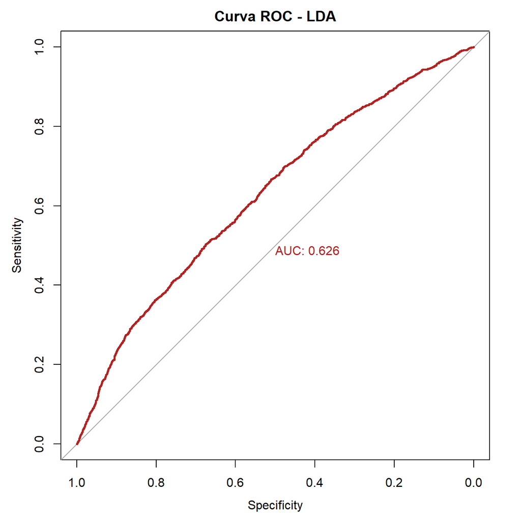

```r
par(pty = "s")
roc_lda <- roc(test$grupo_anemia, pred_lda$posterior[, "Con_anemia"],
               levels = c("Sin_anemia", "Con_anemia"))

plot(roc_lda, col = "firebrick", main = "Curva ROC - LDA", print.auc = TRUE, lwd = 2.5)
```

```r
cat("AUC LDA =", round(auc(roc_lda), 4), "\n")
```

```
## AUC LDA = 0.626
```

# 10 Paso 6: Prediccion para un caso nuevo

Clasificamos un nino hipotetico de 24 meses, 11.5 kg, 84 cm, Z talla/edad = -1.2, Z peso/edad = -0.8:

```r
nuevo_caso <- data.frame(
  edad_meses = 24,
  peso_kg = 11.5,
  talla_cm = 84,
  talla_edad_z = -1.2,
  peso_edad_z = -0.8
)
kable(nuevo_caso, caption = "Nuevo caso a clasificar")
```

Nuevo caso a clasificar

| edad_meses | peso_kg | talla_cm | talla_edad_z | peso_edad_z |
| --- | --- | --- | --- | --- |
| 24 | 11.5 | 84 | -1.2 | -0.8 |

```r
cat("Prediccion LDA:\n")
```

```
## Prediccion LDA:
```

```r
predict(modelo_lda, newdata = nuevo_caso)
```

```
## $class
## [1] Sin_anemia
## Levels: Con_anemia Sin_anemia
##
## $posterior
##   Con_anemia Sin_anemia
## 1  0.3376413  0.6623587
##
## $x
##          LD1
## 1 -0.3205727
```

# 11 Visualizacion de las regiones de clasificacion

La funcion `partimat()` del paquete `klaR` muestra, para cada par de predictores, las regiones de clasificacion del modelo LDA:

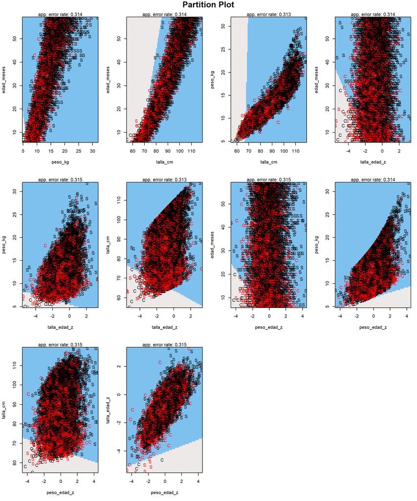

```r
partimat(grupo_anemia ~ edad_meses + peso_kg + talla_cm + talla_edad_z + peso_edad_z,
         data = train, method = "lda", prec = 100,
         image.colors = c("snow2", "skyblue2"), col.mean = "firebrick")
```

# 12 Guardar resultados

```r
pred_total_lda <- predict(modelo_lda, newdata = datos)

resultado <- cbind(datos,
                    pred_LDA = pred_total_lda$class,
                    prob_Con_anemia_LDA = pred_total_lda$posterior[, "Con_anemia"])

write.csv(resultado, "tabla_predicciones_anemia_LDA_R.csv", row.names = FALSE)
cat("Archivo guardado: tabla_predicciones_anemia_LDA_R.csv\n")
```

```
## Archivo guardado: tabla_predicciones_anemia_LDA_R.csv
```

```r
kable(head(resultado, 10), caption = "Primeras 10 filas de la tabla de predicciones")
```

Primeras 10 filas de la tabla de predicciones

|  | edad_meses | peso_kg | talla_cm | talla_edad_z | peso_edad_z | anemia_oms | grupo_anemia | pred_LDA | prob_Con_anemia_LDA |
| --- | --- | --- | --- | --- | --- | --- | --- | --- | --- |
| 1 | 43 | 15.0 | 96.2 | -0.88 | -0.10 | 4 | Sin_anemia | Sin_anemia | 0.2519795 |
| 2 | 13 | 9.1 | 71.4 | -1.67 | -0.17 | 4 | Sin_anemia | Sin_anemia | 0.4685115 |
| 3 | 19 | 11.9 | 80.2 | -0.78 | 0.91 | 4 | Sin_anemia | Sin_anemia | 0.3547751 |
| 4 | 13 | 10.0 | 74.7 | -0.27 | 0.67 | 2 | Con_anemia | Sin_anemia | 0.4180803 |
| 5 | 18 | 11.2 | 79.5 | -1.19 | 0.13 | 4 | Sin_anemia | Sin_anemia | 0.3648839 |
| 6 | 54 | 16.7 | 101.2 | -1.19 | -0.25 | 4 | Sin_anemia | Sin_anemia | 0.2418050 |
| 7 | 21 | 9.6 | 77.7 | -2.05 | -1.07 | 4 | Sin_anemia | Sin_anemia | 0.4061913 |
| 8 | 42 | 14.3 | 96.7 | -0.87 | -0.62 | 4 | Sin_anemia | Sin_anemia | 0.2408008 |
| 9 | 53 | 14.6 | 103.0 | -0.67 | -1.14 | 3 | Con_anemia | Sin_anemia | 0.2065022 |
| 11 | 14 | 9.9 | 76.7 | -0.24 | 0.28 | 2 | Con_anemia | Sin_anemia | 0.3911117 |

# 13 Conclusiones

- El dataset final quedo con **18306** observaciones validas, de un total de **20290** registros originales.
- El test M de Box dio un p-value de **< 0.00000000000000022**, lo que indica que las matrices de covarianza no son homogeneas entre grupos (limitacion a considerar).
- El Lambda de Wilks fue **0.0018** (p-value < 0.00000000000000022), lo que indica que la funcion discriminante SI es estadisticamente significativa.
- En el conjunto de prueba, el LDA obtuvo un error de clasificacion de **31.4%** (accuracy de **68.6%**).
- El AUC del modelo LDA fue de **0.626**.